# Spring 2022 CHEM 272 Lab 1 Answers

gtluu

05/06/2022

# Introduction

Below is the protocol that was used to find the identity of the mystery protein (semi-)programmatically. It should be noted that this is by no means the only way to annotate our protein. This document should simply be considered a reference for those who may perform similar experiments on the MALDI in the future.

# R Script Setup

### Library Imports

Start by importing the packages that will be used for your analysis.

```r
library(rmarkdown)
library(MALDIquant)
library(MALDIquantForeign)
library(fuzzyjoin)
```

### Set Working Directory

Set the working directory to a folder containing your mzML files. Here you could analyze tthe dataset containing spectra acquired using a lower laser power, higher laser power, or combined dataset with both.

```r
# Microflex low laser 40%-50%
setwd('C:/Users/gordon/Data/chem272_lab/lab1/digest/mzml_low')
# Microflex high laser 70%-80%
setwd('C:/Users/gordon/Data/chem272_lab/lab1/digest/mzml_high')
# Microflex combined
setwd('C:/Users/gordon/Data/chem272_lab/lab1/digest/mzml')
```

# Data Import and Preprocessing

### Import Data

Import the data to MALDIquant using MALDIquantForeign

```r
spectra_list_raw <- import('C:/Users/gordon/Data/chem272_lab/lab1/digest/mzml')
```

### Set Working Directory

Optionally, set the working directory to somewhere you’d like to save your R data.

```r
setwd('C:/Users/gordon/Data/chem272_lab/lab1/r')
```

### Import In Silico Digest Peak Lists

Import peak lists for *in silico* that were downloaded from [Expasy PeptideMass](https://web.expasy.org/peptide_mass/). To make our life easier later, we will put them into a `named_list`.

```r
# P62937
ppia_1 <- read.table('ppia_1.txt', col.names=c('mz'))
ppia_2 <- read.table('ppia_2.txt', col.names=c('mz'))
# Q9UNP9
ppie <- read.table('ppie.txt', col.names=c('mz'))
# P30405
ppif <- read.table('ppif.txt', col.names=c('mz'))
# Q13427
ppig <- read.table('ppig.txt', col.names=c('mz'))
# O43447
ppih <- read.table('ppih.txt', col.names=c('mz'))
# Q9Y3C6
ppil1 <- read.table('ppil1.txt', col.names=c('mz'))
# Q13356
ppil2 <- read.table('ppil2.txt', col.names=c('mz'))
# Q9H2H8
ppil3 <- read.table('ppil3.txt', col.names=c('mz'))
# Q96BP3
ppwd <- read.table('ppwd.txt', col.names=c('mz'))
# Q6UX04
cwc27 <- read.table('cwc27.txt', col.names=c('mz'))

# List of Peak Lists
peak_lists <- list('ppia_1'=ppia_1,
                   'ppia_2'=ppia_2,
                   'ppie'=ppie,
                   'ppif'=ppif,
                   'ppig'=ppig,
                   'ppih'=ppih,
                   'ppil1'=ppil1,
                   'ppil2'=ppil2,
                   'ppil3'=ppil3,
                   'ppwd'=ppwd,
                   'cwc27'=cwc27)
```

### Preprocessing Parameters

```r
snr <- 4
tol <- 0.5
```

### Preprocessing

Preprocessing (among other things) will normalize the intensity across replicates/different samples and align spectra to account for drift on the *m/z* axis.

```r
# Trim the data to the mass range we acquired.
spectra_list <- trim(spectra_list_raw,
                     c(500, 3000))
# Sqaure root transformation of intensity values.
# Causes intensity values to be small.
spectra_list <- transformIntensity(spectra_list,
                                   method='sqrt')
# Baseline smoothing via SavitzkyGolay algorithm.
spectra_list <- smoothIntensity(spectra_list,
                                method='SavitzkyGolay',
                                halfWindowSize=10)
# Baseliine removal via SNIP algorithm.
spectra_list <- removeBaseline(spectra_list,
                               method='SNIP',
                               iterations=100)
# Intensity normalization via the total ion count algorithm.
spectra_list <- calibrateIntensity(spectra_list,
                                   method='TIC')
# Spectra alignment via the lowess algorithm.
spectra_list <- alignSpectra(spectra_list,
                             halfWindowSize=20,
                             SNR=snr,
                             tolerance=tol,
                             noiseMethod='MAD',
                             warpingMethod='lowess')
```

### Peak Picking

Peak picking centroids (or re-centroids) data and provides a peak list for each spectrum imported.

```r
# Peak picking via the mean absolute deviation deviation
peaks <- detectPeaks(spectra_list,
                     method='MAD',
                     halfWindowSize=20,
                     SNR=snr)
```

### Get Peak List

We generate an intensity matrix in which each column is a an *m/z* feature and each row is a separate file/spectrum. This matrix shows you the intensity value of a given feature in each spectrum. However, in this experiment, we are not doing any sort of quantification. Therefore, we only care about getting a consensus peak list from this matrix.

```r
# Generate feature matrix.
featureMatrix <- intensityMatrix(peaks, spectra_list)
# Use the column names (m/z features) to create a one-column dataframe labeled 'mz'.
features <- data.frame('mz'=as.numeric(colnames(featureMatrix)))
```

# Compare Peak List to In Silico Digest Peak Lists

In the next step, we will use this peak list to compare our experimental features to theoretical features found in our *in silico* digests. Matching experimental peaks can be used to perform a [MASCOT Peptide Mass Fingerprint search](https://www.matrixscience.com/cgi/search_form.pl?FORMVER=2&SEARCH=PMF). During peak list comparison, it is best to start with a low tolerance and incrementally increase it if no matches can be found. The `difference_inner_join` function from the `fuzzyjoin` package can be used to compare 2 `data.frames` and return peaks that match ± a specified tolerance (in this case, 0.1 Da, 0.2 Da, or 0.5 Da).

### 0.1 Da Tolerance

```r
for (i in 1:length(peak_lists)) {
  tolerance <- 0.1
  df <- difference_inner_join(peak_lists[[i]], features,
                                by='mz', max_dist=tolerance)
  colnames(df) <- c(paste(names(peak_lists)[i], tolerance, 'theoretical', sep='_'),
                    paste(names(peak_lists)[i], tolerance, 'experimental', sep='_'))
  print(df)
}
```

```
##   ppia_1_0.1_theoretical ppia_1_0.1_experimental
## 1               728.4089                728.4426
## 2               571.2874                571.1950
##   ppia_2_0.1_theoretical ppia_2_0.1_experimental
## 1               728.4089                728.4426
## 2               571.2874                571.1950
## [1] ppie_0.1_theoretical  ppie_0.1_experimental
## <0 rows> (or 0-length row.names)
##   ppif_0.1_theoretical ppif_0.1_experimental
## 1             767.3934              767.3640
## 2             742.4709              742.4097
## 3             571.2874              571.1950
##   ppig_0.1_theoretical ppig_0.1_experimental
## 1            1080.5506             1080.5891
## 2             948.4646              948.5092
## 3             948.4646              948.5145
## 4             871.4519              871.4147
## 5             835.3792              835.4435
## 6             542.3157              542.3907
## [1] ppih_0.1_theoretical  ppih_0.1_experimental
## <0 rows> (or 0-length row.names)
##   ppil1_0.1_theoretical ppil1_0.1_experimental
## 1               802.373               802.3392
##   ppil2_0.1_theoretical ppil2_0.1_experimental
## 1              2331.207               2331.112
## 2              1013.494               1013.431
##   ppil3_0.1_theoretical ppil3_0.1_experimental
## 1              868.4345               868.3818
##   ppwd_0.1_theoretical ppwd_0.1_experimental
## 1             718.3253              718.2771
##   cwc27_0.1_theoretical cwc27_0.1_experimental
## 1             2135.0841              2135.0011
## 2             2192.1056              2192.0263
## 3             2192.1056              2192.1297
## 4              862.4628               862.5279
```

### 0.2 Da Tolerance

```r
for (i in 1:length(peak_lists)) {
  tolerance <- 0.2
  df <- difference_inner_join(peak_lists[[i]], features,
                                by='mz', max_dist=tolerance)
  colnames(df) <- c(paste(names(peak_lists)[i], tolerance, 'theoretical', sep='_'),
                    paste(names(peak_lists)[i], tolerance, 'experimental', sep='_'))
  print(df)
}
```

```
##   ppia_1_0.2_theoretical ppia_1_0.2_experimental
## 1               728.4089                728.4426
## 2               571.2874                571.1950
##   ppia_2_0.2_theoretical ppia_2_0.2_experimental
## 1               728.4089                728.4426
## 2               571.2874                571.1950
##   ppie_0.2_theoretical ppie_0.2_experimental
## 1             551.2857               551.185
##   ppif_0.2_theoretical ppif_0.2_experimental
## 1             995.5044              995.6745
## 2             767.3934              767.3640
## 3             742.4709              742.4097
## 4             628.3664              628.1952
## 5             571.2874              571.1950
##    ppig_0.2_theoretical ppig_0.2_experimental
```

[output cut: 45 more lines]

### 0.5 Da Tolerance

```r
for (i in 1:length(peak_lists)) {
  tolerance <- 0.5
  df <- difference_inner_join(peak_lists[[i]], features,
                                by='mz', max_dist=tolerance)
  colnames(df) <- c(paste(names(peak_lists)[i], tolerance, 'theoretical', sep='_'),
                    paste(names(peak_lists)[i], tolerance, 'experimental', sep='_'))
  print(df)
}
```

```
##   ppia_1_0.5_theoretical ppia_1_0.5_experimental
## 1              1258.5786               1258.3253
## 2              1257.6473               1258.0245
## 3               848.4148                848.7267
## 4               728.4089                728.4426
## 5               571.2874                571.1950
##   ppia_2_0.5_theoretical ppia_2_0.5_experimental
## 1              1258.5786               1258.3253
## 2              1257.6473               1258.0245
## 3               848.4148                848.7267
## 4               728.4089                728.4426
## 5               571.2874                571.1950
##    ppie_0.5_theoretical ppie_0.5_experimental
## 1             2950.3471             2950.0362
## 2             2177.9304             2178.3208
```

[output cut: 117 more lines]

# Compare Peak List to In Silico Digest Peak Lists for Proteins in Mass Range of Interest

As seen in the previous section, as the tolerance used to match experimental and theoretical peptide features is increased, it becomes difficult to determine your protein identity. Therefore, we should filter the out the proteins that are outside of our mass range of interest.

## Determining the Approximate Mass of an Unknown Protein

MALDI-TOF mass spectrometry is useful for analyzing large proteins when using a linear time-of-flight tube.

### Set Working Directory

```r
# Microflex Intact Protein
setwd('C:/Users/gordon/Data/chem272_lab/lab1/intact/mzml')
```

### Import Data

```r
intact_raw <- import('C:/Users/gordon/Data/chem272_lab/lab1/intact/mzml')
```

### Set Working Directory

```r
# Microflex Intact Protein
setwd('C:/Users/gordon/Data/chem272_lab/lab1/r')
```

### Peak Picking

Peak picking is performed to obtain peak labels.

```r
# Peak picking via the mean absolute deviation deviation
peaks <- detectPeaks(intact_raw,
                     method='MAD',
                     halfWindowSize=20,
                     SNR=snr)
```

### Plotting Intact Protein Spectrum

Plot intact protein spectrum. In the lab, we initially acquired data with a mass range of *m/z* 10,000 - 100,000 in which we determined the intact mass was roughly 18,000 Da. Subsequently, we acquired data in the mass range of *m/z* 10,000 - 25,000 to obtain a calibrated, more accurate mass. In this data, we see our intact protein mass is 18,055 Da (*m/z* 18,056).

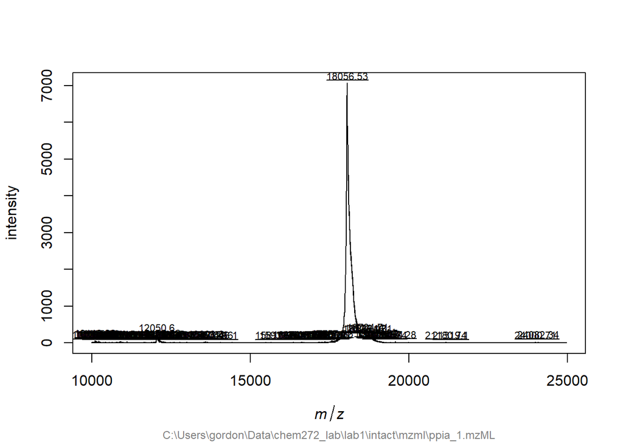

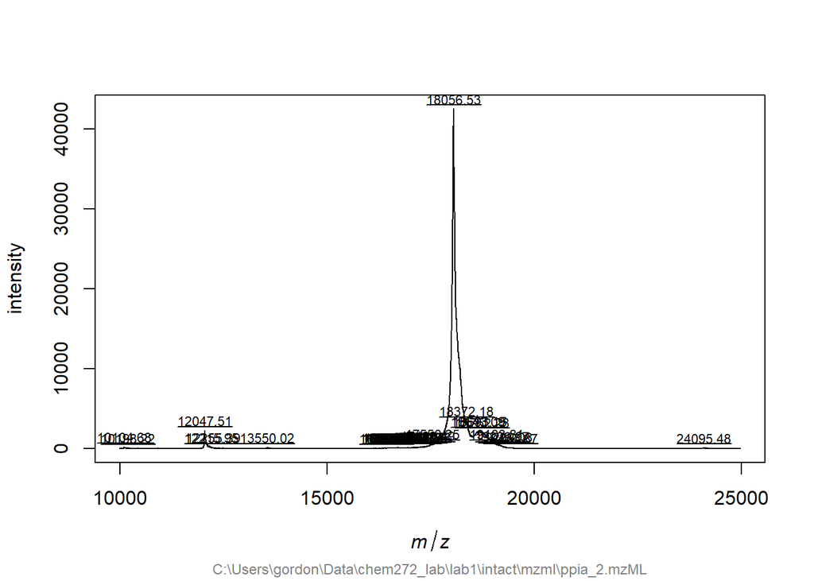

```r
for (i in c(1, 2)) {
  plot(intact_raw[[i]]) +
    labelPeaks(peaks[[i]])
}
```

### Modified Protein List Based on Intact Mass

Based on our intact protein mass of 18,055 Da, PPIA, PPIH, PPIL1, and PPIL3 are four proteins that fall into our mass range of interest. Therefore, we will shorten our list of peak lists to compare to our data. We now have a much more manageable list of potential identities.

```r
# List of Peak Lists
peak_lists <- list('ppia_1'=ppia_1,
                   'ppia_2'=ppia_2,
                   'ppih'=ppih,
                   'ppil1'=ppil1,
                   'ppil3'=ppil3)
```

### 0.1 Da Tolerance

Here, we see that PPIA has 2 matching peaks, PPIL1 and PPIL3 have 1 matching peak, and PPIH has none.

```r
for (i in 1:length(peak_lists)) {
  tolerance <- 0.1
  df <- difference_inner_join(peak_lists[[i]], features,
                                by='mz', max_dist=tolerance)
  colnames(df) <- c(paste(names(peak_lists)[i], tolerance, 'theoretical', sep='_'),
                    paste(names(peak_lists)[i], tolerance, 'experimental', sep='_'))
  print(df)
}
```

```
##   ppia_1_0.1_theoretical ppia_1_0.1_experimental
## 1               728.4089                728.4426
## 2               571.2874                571.1950
##   ppia_2_0.1_theoretical ppia_2_0.1_experimental
## 1               728.4089                728.4426
## 2               571.2874                571.1950
## [1] ppih_0.1_theoretical  ppih_0.1_experimental
## <0 rows> (or 0-length row.names)
##   ppil1_0.1_theoretical ppil1_0.1_experimental
## 1               802.373               802.3392
##   ppil3_0.1_theoretical ppil3_0.1_experimental
## 1              868.4345               868.3818
```

### 0.2 Da Tolerance

Results are similar to the 0.1 Da tolerance comparison with the exception of PPIL3, which now has 2 matching peaks.

```r
for (i in 1:length(peak_lists)) {
  tolerance <- 0.2
  df <- difference_inner_join(peak_lists[[i]], features,
                                by='mz', max_dist=tolerance)
  colnames(df) <- c(paste(names(peak_lists)[i], tolerance, 'theoretical', sep='_'),
                    paste(names(peak_lists)[i], tolerance, 'experimental', sep='_'))
  print(df)
}
```

```
##   ppia_1_0.2_theoretical ppia_1_0.2_experimental
## 1               728.4089                728.4426
## 2               571.2874                571.1950
##   ppia_2_0.2_theoretical ppia_2_0.2_experimental
## 1               728.4089                728.4426
## 2               571.2874                571.1950
## [1] ppih_0.2_theoretical  ppih_0.2_experimental
## <0 rows> (or 0-length row.names)
##   ppil1_0.2_theoretical ppil1_0.2_experimental
## 1               802.373               802.2641
## 2               802.373               802.3392
##   ppil3_0.2_theoretical ppil3_0.2_experimental
## 1             2218.1172              2218.2476
## 2              868.4345               868.2954
## 3              868.4345               868.3818
```

### 0.5 Da Tolerance

By expanding the tolerance to 0.5 Da, we now have many more matches. However, due to the increased tolerance, the chances of false positive matches has increased. PPIA now has 5 matches, PPIH has 2 matches, PPIL1 has 3 matches (notice the duplicates), and PPIL3 has 3 matches

```r
for (i in 1:length(peak_lists)) {
  tolerance <- 0.5
  df <- difference_inner_join(peak_lists[[i]], features,
                                by='mz', max_dist=tolerance)
  colnames(df) <- c(paste(names(peak_lists)[i], tolerance, 'theoretical', sep='_'),
                    paste(names(peak_lists)[i], tolerance, 'experimental', sep='_'))
  print(df)
}
```

```
##   ppia_1_0.5_theoretical ppia_1_0.5_experimental
## 1              1258.5786               1258.3253
## 2              1257.6473               1258.0245
## 3               848.4148                848.7267
## 4               728.4089                728.4426
## 5               571.2874                571.1950
##   ppia_2_0.5_theoretical ppia_2_0.5_experimental
## 1              1258.5786               1258.3253
## 2              1257.6473               1258.0245
## 3               848.4148                848.7267
## 4               728.4089                728.4426
## 5               571.2874                571.1950
##   ppih_0.5_theoretical ppih_0.5_experimental
## 1            2869.3066             2868.8176
## 2             848.4512              848.7267
##   ppil1_0.5_theoretical ppil1_0.5_experimental
## 1              848.4876               848.7267
## 2              802.3730               802.2641
## 3              802.3730               802.3392
## 4              784.4134               783.9630
## 5              784.4134               784.0287
##   ppil3_0.5_theoretical ppil3_0.5_experimental
## 1             2610.1322              2609.6481
## 2             2218.1172              2217.8850
## 3             2218.1172              2218.2476
## 4              868.4345               868.2954
## 5              868.4345               868.3818
```

# Determining Our Protein Identity

Using the peak lists from the 0.5 Da tolerance comparison between theoretical and experimental tryptic peptides, I obtained the following results:

| Protein | MASCOT Score | Matching Peptides |
| --- | --- | --- |
| PPIA | 40 | 4 |
| PPIH | 38 | 2 |
| PPIL1 | 26 | 2 |
| PPIL3 | - | - |

Here, we can see PPIA had the highest peptide mass fingerprint score as well as the highest number of matching peptides. Therefore, of all of our potential hits, PPIA appears to be the identity of our mystery protein. With that being said, because we only have low resolution MS1 data, it would be ideal to follow up on this by collecting MS/MS data to perform peptide sequencing followed by database searching using SEQUEST, MaxQuant, etc.